# R Notebook

```r
library(tidyverse)
library(leaflet)
```

library(tidycensus)

library(dataRetrieval)

library(rnoaa)

In today’s lecture we are going to learn how to make use of a number of R packages that allow you to directly query and access data from some notable environmental databases. These data access packages are incredibly powerful as they allow you to streamline your workflow by combining the data identification and acquisition steps directly with your data analysis. They also provide a highly efficient and reproducible approach to data identification and acquisition - allowing you to easily adapt or expand your research question with minimal additional effort.

There are many packages that have been developed for accessing data through R, including a wide range of packages for accessing environmental datasets. Today we will look at a few notable packages and in the coming weeks we will explore some additional ones. The packages below highlight a number of notable research-quality datasets that are likely to be useful in many of your class projects, theses, and future research/work.

## Climate data

In much of our environmental research we need to use climate/meteorological data. While there are a host of organization/agencies that provide freely available research quality datasets, locating and accessing the data can often be time-consuming and difficult. Furthermore, once you’ve located the data (generally through the website of the agency/organization collecting the data) you typically need to download the file (e.g., csv, Excel), load it into R, and reformat the data for your analysis. The R packages below allow you to quickly locate the data of interest and directly load it into R in a format that is ready to use in R - typically all within a single function call!

### GSODR package

We will learn how to use the [`GSODR` package](https://docs.ropensci.org/GSODR/) to directly access this data.

First let’s load in the package (FYI, you will need to install the package first if you have not installed it before)

https://cran.r-project.org/web/packages/GSODR/vignettes/GSODR.html

```r
library(GSODR)
```

The package comes with a dataset that has all of the available meteorological stations and their location information/details (e.g., lat/long, country, state, period of data coverage). We will load in this data below.

```r
load(system.file("extdata", "isd_history.rda", package = "GSODR"))
```

```
Error in dirname(to) : path too long
```

If you identified a station(s) of interest you can download the data using the `get_GSOD()` function. Let’s try this out for Windhoek, which is the capital of the country of Namibia (located in SW Africa). To download data for a given station, you need to supply the station ID (STNID) and the years of interest. You can locate the STNID in the `isd_history` data frame.

725090-14739

```r
met_df <- get_GSOD(years = 2018:2021, station = "681100-99999")
```

Take a look at the `met_df` data frame. The description of the variables can [be found here](https://docs.ropensci.org/GSODR/articles/GSODR.html#appendices).

Let’s plot the a time-series of the daily minimum and maximum air temperatures from 2018-2021 at the selected met station.

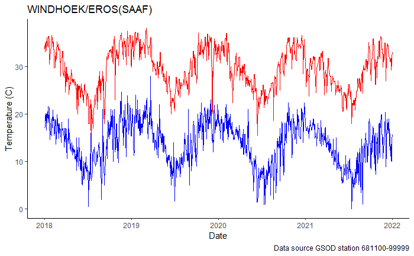

```r
met_df %>%
  ggplot() +
  geom_line(aes(x = YEARMODA, y = MIN), color = "blue") +
  geom_line(aes(x = YEARMODA, y = MAX), color = "red") +

  labs(title = met_df$NAME[1],
       x = "Date",
       y = "Temperature (C)",
       caption = paste("Data source GSOD station", met_df$STNID[1])
       ) +

  theme_classic()
```

Oftentimes you have a study location/area of interest and you would like to identify any/all meterological stations that exist nearby your site. The `GSODR` package has a really helpful function, `nearest_stations()` that does this. You need to supply the lat/long of the area to query and the radial distance (in kilometers) from your search point. The function will then return a list of the STNID with the station info for all stations that fall within your search radius.

Let’s test this out by searching for all of the stations within 25 km of Schenectady.

```r
schdy_met_stations <- nearest_stations(LAT = 42.81,
                                  LON = -73.94,
                                  distance = 25)


schdy_met_stations
```

```
[1] "744994-99999" "999999-14735" "725180-14735"
```

We can see that there are 3 meteorological stations within 25 km of Schenectady.

- Download the data from 2010-2015 for the stations nearby Schenectady
- Try downloading meteorological data for a location you are interested in. Create some figures and/or tables that provide insight into that locations meteorological conditions.

## Hydrological data

The USGS [National Water Information Service (NWIS)](https://waterdata.usgs.gov/nwis) is an incredible database containing physical and chemical data on the streams/rivers, lakes, and groundwater for nearly 2 million locations across the US and US territories. From NWIS you can download data related to thousands of different parameters including streamflow, groundwater levels, and a wide range of water chemistry and physical conditions.

### dataRetrieval

http://usgs-r.github.io/dataRetrieval/articles/tutorial.html

```r
library(dataRetrieval)
```

https://waterservices.usgs.gov/rest/Site-Service.html

```r
sites_schdy_flow <- whatNWISsites(countyCd = "36093", parameterCd = "00060")

sites_NY_flow <- whatNWISsites(stateCd = "NY", parameterCd = "00060")
```

```r
flowAndTemp <- whatNWISdata(siteNumber = sites_NY_flow$site_no, service = "uv",
                             parameterCd = c("00060","00010"),
                             statCd = "00003")
```

```r
siteINFO <- readNWISsite(sites_schdy_flow$site_no)
```

```r
comment(siteINFO)
```

### streamflow example

### water quality example

## rnoaa

## stationaRy

## elevatr

## rWBclimate

https://docs.ropensci.org/rWBclimate/

## ebird

https://cran.r-project.org/web/packages/rebird/vignettes/rebird_vignette.html

```r
ebird_key <- "c2jlhls8h84c"
```

```r
library(rebird)
```

```r
species_code('Accipiter cooperii')
```

```
Cooper's Hawk (Accipiter cooperii): coohaw
```

```
[1] "coohaw"
```

```r
new_tax <- ebirdtaxonomy()
```

Sialia sialis Haliaeetus leucocephalus Accipiter cooperii

```r
a <- ebirdgeo(species = species_code('Accipiter cooperii'), lat = 42.8, lng = -73.9, back = 30, dist = 50,
              key = ebird_key)
```

```
Cooper's Hawk (Accipiter cooperii): coohaw
```

```r
b <- ebirdgeo(lat = 42.8, lng = -73.9, back = 30,
              key = ebird_key)
```

```r
fig_map <- a %>%
  leaflet() %>%
  addProviderTiles(providers$Esri.NatGeoWorldMap) %>%
  addMarkers(~ lng, ~ lat, popup = ~ paste(comName, "; n:", howMany))
```